# Personal Activity Predictive Modeling

Paul Ighofose

8/13/2021

## About

Due to technological advances, devices such as Jawbone, Nike FuelBand, and Fitbit have now made personal activity data more accessible and inexpensive to collect. The goal of this project is to utilize self-movement measurements collected by a group of enthusiasts to model and predict the class of each exercise recorded.

Access to training and testing data are provided via the following links:

Training data:

https://d396qusza40orc.cloudfront.net/predmachlearn/pml-training.csv

Testing data:

https://d396qusza40orc.cloudfront.net/predmachlearn/pml-testing.csv

## Methods

To begin, the tidyverse and caret packages were loaded into the IDE for data manipulation. A working directory was established to store initial and proceeding data. The data was uploaded and assigned a variable to begin manipulation.

Upon initial assessment, the training and testing data consisted of 160 features with 19,622 and 20 obseravations, respectively. Of those features, 66.88% of the features are of "NA" value and will not influence modeling or the predictive outcome. Thus, those features were removed to provide tidied, consistent data.

```
## [1] 19622   160
```

```
## [1]  20 160
```

However, upon further investigation, the testing data lacks the "classe" feature, which is vital to building a classification model upon this data set. Furthermore, this outcome could be supplemented by exploring the quantitative data (i.e. roll_belt, yaw_dumbbell, etc.) and how it correlates to one another. Yet, doing so seems unpromising. Unpromising because the data set indicates the location of each accelerometer and gyroscope without fully specifying the exact type of barbell lift performed. For instance, one would assume for dumbbell curls the accelerometer and gyroscope would indicate heightened positive and negative movement along the "y-axis" (up and down movements), with minimal variation along the "x-axis" (left to right), if correctly performed. This is significant because to accurately determine the correlating increase and decrease of axial movements, as in a chest press with barbells, that feature should be named accordingly, to adequately describe the exercise, which implicitly infers a related axial movement. Consequentially, this is not the case and one cannot solely rely upon the quantitative data because its features are not precisely represented.

To overcome this discrepancy, the data was partitioned and a k-fold cross validation method was performed on the training data set:

1: To yield a test data set with the "classe" outcome feature.

2: Provide a variation in the training data to produce a more accurate model.

```
## [1] 19602    53
```

```
## [1] 20 53
```

To model the data, a generalized linear regression method would suffice, however to boost accuracy, a gradient boosting method was employed. The outcome yielded 100% accurracy, predicting correctly each class of the 20 exercises presented within the partitioned testing data set.

```r
model
```

```
## Stochastic Gradient Boosting
##
## 19602 samples
##    52 predictor
##     5 classes: 'A', 'B', 'C', 'D', 'E'
##
## No pre-processing
## Resampling: Cross-Validated (10 fold)
## Summary of sample sizes: 17641, 17642, 17641, 17642, 17644, 17641, ...
## Resampling results across tuning parameters:
##
##   interaction.depth  n.trees  Accuracy  Kappa
##   1                   50      0.999694  0.999613
##   1                  100      0.999694  0.999613
##   1                  150      0.999694  0.999613
##   2                   50      0.999694  0.999613
##   2                  100      0.999694  0.999613
##   2                  150      0.999694  0.999613
##   3                   50      0.999694  0.999613
##   3                  100      0.999694  0.999613
##   3                  150      0.999694  0.999613
##
## Tuning parameter 'shrinkage' was held constant at a value of 0.1
##
## Tuning parameter 'n.minobsinnode' was held constant at a value of 10
## Accuracy was used to select the optimal model using the largest value.
## The final values used for the model were n.trees = 50, interaction.depth =
##  1, shrinkage = 0.1 and n.minobsinnode = 10.
```

```r
#Modeling data and utilizing predictive model to determine outcome on Testing data set:
```

```
## A gradient boosted model with multinomial loss function.
## 50 iterations were performed.
## There were 52 predictors of which 1 had non-zero influence.
```

```
## Confusion Matrix and Statistics
##
##           Reference
## Prediction A B C D E
##          A 5 0 0 0 0
##          B 0 4 0 0 0
##          C 0 0 4 0 0
##          D 0 0 0 3 0
##          E 0 0 0 0 4
##
## Overall Statistics
##
##                Accuracy : 1
##                  95% CI : (0.8316, 1)
##     No Information Rate : 0.25
##     P-Value [Acc > NIR] : 9.095e-13
##
##                   Kappa : 1
##
##  Mcnemar's Test P-Value : NA
##
## Statistics by Class:
##
##                      Class: A Class: B Class: C Class: D Class: E
## Sensitivity              1.00      1.0      1.0     1.00      1.0
## Specificity              1.00      1.0      1.0     1.00      1.0
## Pos Pred Value           1.00      1.0      1.0     1.00      1.0
## Neg Pred Value           1.00      1.0      1.0     1.00      1.0
## Prevalence               0.25      0.2      0.2     0.15      0.2
## Detection Rate           0.25      0.2      0.2     0.15      0.2
## Detection Prevalence     0.25      0.2      0.2     0.15      0.2
## Balanced Accuracy        1.00      1.0      1.0     1.00      1.0
```

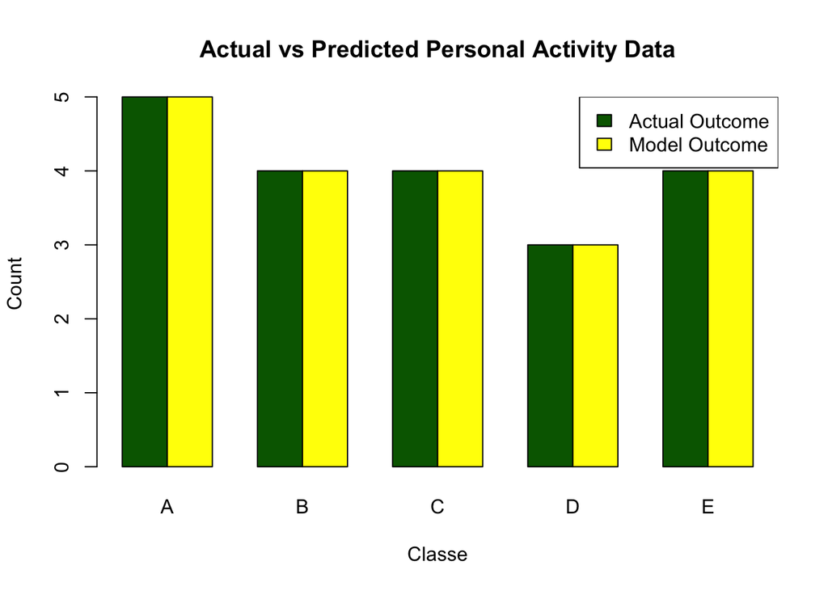